# Project SUL- Bank Loan_solution v1

## Thera Bank Personal Loan Campaign

## Context

This case is about a bank (TheraBank) whose management wants to explore ways of converting its liability customers to personal loan customers (while retaining them as depositors). A campaign that the bank ran last year for liability customers showed a healthy conversion rate of over 9% success. This has encouraged the retail marketing department to devise campaigns with better target marketing to increase the success ratio with a minimal budget.

## Objective

The classification goal is to predict the likelihood of a liability customer buying personal loans. The target variable in this dataset is 'Personal Loan'.

## Attribute Information:

- ID: CustomerID
- Age: Customer's age in completedyears
- Experience: #years of professionalexperience
- Income: Annual income of the customer(000)
- ZIP Code: Home Address ZIPcode.
- Family: Family size of thecustomer
- CCAvg: Avg. spending on credit cards per month(000)
- Education: Education Level. 1: Undergrad; 2: Graduate;3: Advanced/Professional
- Mortgage: Value of house mortgage if any.(000)
- Personal Loan: Did this customer accept the personal loan offered in the last campaign?
- Securities Account: Does the customer have a securities account with the bank?
- CD Account: Does the customer have a certificate of deposit (CD) account with the bank?
- Online: Does the customer use internet banking facilities?
- CreditCard: Does the customer use a credit card issued by the bank?

## Index

- Q1 - Import Libraries and Load Dataset
- Q2 - EDA
- Q3 - Split the data into training and test set
- Q4 - Build the Logistic Regression model
- Q5 - Show coefficients of all the attributes in a data frame with column names
- Q6 - Business Insights

### 1. Import the datasets and libraries, check datatype, statistical summary,shape,null values or incorrect imputation. (5 marks)

```python
import warnings
warnings.filterwarnings('ignore')
```

```python
## importing libaries

import pandas as pd
import numpy as np
import matplotlib.pyplot as plt
%matplotlib inline
import seaborn as sns
```

```python
# importing data

df = pd.read_csv("Bank_Personal_Loan_Modelling.csv")
df.head()      # used to see top 5 rows of the dataset
```

|  | ID | Age | Experience | Income | ZIP Code | Family | CCAvg | Education | Mortgage | Personal Loan | Securities Account | CD Account | Online | CreditCard |
| --- | --- | --- | --- | --- | --- | --- | --- | --- | --- | --- | --- | --- | --- | --- |
| 0 | 1 | 25 | 1 | 49 | 91107 | 4 | 1.6 | 1 | 0 | 0 | 1 | 0 | 0 | 0 |
| 1 | 2 | 45 | 19 | 34 | 90089 | 3 | 1.5 | 1 | 0 | 0 | 1 | 0 | 0 | 0 |
| 2 | 3 | 39 | 15 | 11 | 94720 | 1 | 1.0 | 1 | 0 | 0 | 0 | 0 | 0 | 0 |
| 3 | 4 | 35 | 9 | 100 | 94112 | 1 | 2.7 | 2 | 0 | 0 | 0 | 0 | 0 | 0 |
| 4 | 5 | 35 | 8 | 45 | 91330 | 4 | 1.0 | 2 | 0 | 0 | 0 | 0 | 0 | 1 |

```python
df.shape
```

```
(5000, 14)
```

```python
df.nunique()
```

```
ID                    5000
Age                     45
Experience              47
Income                 162
ZIP Code               467
Family                   4
CCAvg                  108
Education                3
Mortgage               347
Personal Loan            2
Securities Account       2
CD Account               2
Online                   2
CreditCard               2
dtype: int64
```

```python
df.dtypes        ## this would give datatype of each column
```

```
ID                      int64
Age                     int64
Experience              int64
Income                  int64
ZIP Code                int64
Family                  int64
CCAvg                 float64
Education               int64
Mortgage                int64
Personal Loan           int64
Securities Account      int64
CD Account              int64
Online                  int64
CreditCard              int64
dtype: object
```

```python
df.describe().T
```

|  | count | mean | std | min | 25% | 50% | 75% | max |
| --- | --- | --- | --- | --- | --- | --- | --- | --- |
| ID | 5000.0 | 2500.500000 | 1443.520003 | 1.0 | 1250.75 | 2500.5 | 3750.25 | 5000.0 |
| Age | 5000.0 | 45.338400 | 11.463166 | 23.0 | 35.00 | 45.0 | 55.00 | 67.0 |
| Experience | 5000.0 | 20.104600 | 11.467954 | -3.0 | 10.00 | 20.0 | 30.00 | 43.0 |
| Income | 5000.0 | 73.774200 | 46.033729 | 8.0 | 39.00 | 64.0 | 98.00 | 224.0 |
| ZIP Code | 5000.0 | 93152.503000 | 2121.852197 | 9307.0 | 91911.00 | 93437.0 | 94608.00 | 96651.0 |
| Family | 5000.0 | 2.396400 | 1.147663 | 1.0 | 1.00 | 2.0 | 3.00 | 4.0 |
| CCAvg | 5000.0 | 1.937938 | 1.747659 | 0.0 | 0.70 | 1.5 | 2.50 | 10.0 |
| Education | 5000.0 | 1.881000 | 0.839869 | 1.0 | 1.00 | 2.0 | 3.00 | 3.0 |
| Mortgage | 5000.0 | 56.498800 | 101.713802 | 0.0 | 0.00 | 0.0 | 101.00 | 635.0 |
| Personal Loan | 5000.0 | 0.096000 | 0.294621 | 0.0 | 0.00 | 0.0 | 0.00 | 1.0 |
| Securities Account | 5000.0 | 0.104400 | 0.305809 | 0.0 | 0.00 | 0.0 | 0.00 | 1.0 |
| CD Account | 5000.0 | 0.060400 | 0.238250 | 0.0 | 0.00 | 0.0 | 0.00 | 1.0 |
| Online | 5000.0 | 0.596800 | 0.490589 | 0.0 | 0.00 | 1.0 | 1.00 | 1.0 |
| CreditCard | 5000.0 | 0.294000 | 0.455637 | 0.0 | 0.00 | 0.0 | 1.00 | 1.0 |

```python
df[df.Income==df.Income.min()]
```

|  | ID | Age | Experience | Income | ZIP Code | Family | CCAvg | Education | Mortgage | Personal Loan | Securities Account | CD Account | Online | CreditCard |
| --- | --- | --- | --- | --- | --- | --- | --- | --- | --- | --- | --- | --- | --- | --- |
| 50 | 51 | 32 | 8 | 8 | 92093 | 4 | 0.70 | 2 | 0 | 0 | 1 | 0 | 1 | 0 |
| 291 | 292 | 43 | 16 | 8 | 90089 | 3 | 0.67 | 2 | 88 | 0 | 0 | 0 | 1 | 0 |
| 801 | 802 | 47 | 23 | 8 | 92612 | 4 | 0.20 | 1 | 0 | 0 | 0 | 0 | 1 | 0 |
| 939 | 940 | 56 | 32 | 8 | 93943 | 2 | 0.30 | 1 | 0 | 0 | 0 | 0 | 1 | 1 |
| 1000 | 1001 | 59 | 35 | 8 | 92691 | 4 | 0.70 | 1 | 91 | 0 | 1 | 0 | 0 | 0 |
| 1054 | 1055 | 63 | 38 | 8 | 95136 | 4 | 0.60 | 2 | 0 | 0 | 0 | 0 | 1 | 0 |
| 1197 | 1198 | 48 | 23 | 8 | 92866 | 1 | 0.40 | 3 | 0 | 0 | 0 | 0 | 0 | 1 |
| 1472 | 1473 | 34 | 8 | 8 | 94710 | 3 | 0.10 | 2 | 83 | 0 | 0 | 0 | 1 | 0 |
| 1482 | 1483 | 60 | 35 | 8 | 94143 | 1 | 0.10 | 1 | 0 | 0 | 0 | 0 | 1 | 0 |
| 1720 | 1721 | 52 | 28 | 8 | 95060 | 1 | 0.30 | 1 | 0 | 0 | 0 | 0 | 1 | 0 |
| 2248 | 2249 | 63 | 37 | 8 | 94618 | 1 | 0.80 | 2 | 97 | 0 | 0 | 0 | 1 | 0 |
| 2347 | 2348 | 64 | 39 | 8 | 92104 | 3 | 0.10 | 3 | 87 | 0 | 0 | 0 | 0 | 1 |
| 2354 | 2355 | 35 | 9 | 8 | 94043 | 1 | 0.40 | 2 | 0 | 0 | 0 | 0 | 1 | 0 |
| 2509 | 2510 | 36 | 11 | 8 | 93401 | 4 | 0.20 | 3 | 81 | 0 | 0 | 0 | 0 | 1 |
| 2591 | 2592 | 31 | 7 | 8 | 95131 | 4 | 0.70 | 2 | 0 | 0 | 0 | 0 | 0 | 0 |
| 2695 | 2696 | 40 | 15 | 8 | 94960 | 2 | 0.10 | 2 | 0 | 0 | 0 | 0 | 0 | 0 |
| 2905 | 2906 | 64 | 40 | 8 | 94110 | 2 | 0.30 | 3 | 0 | 0 | 0 | 0 | 1 | 0 |
| 3718 | 3719 | 45 | 19 | 8 | 92833 | 2 | 0.10 | 3 | 0 | 0 | 0 | 0 | 0 | 1 |
| 4094 | 4095 | 53 | 23 | 8 | 95616 | 4 | 0.40 | 3 | 0 | 0 | 1 | 0 | 1 | 0 |
| 4223 | 4224 | 53 | 26 | 8 | 94709 | 1 | 0.50 | 2 | 0 | 0 | 0 | 0 | 0 | 1 |
| 4416 | 4417 | 49 | 25 | 8 | 94720 | 1 | 0.30 | 1 | 97 | 0 | 0 | 0 | 0 | 0 |
| 4507 | 4508 | 26 | 1 | 8 | 94550 | 2 | 0.90 | 3 | 0 | 0 | 0 | 0 | 0 | 1 |
| 4706 | 4707 | 60 | 36 | 8 | 92626 | 2 | 1.00 | 1 | 0 | 0 | 0 | 0 | 0 | 0 |

```python
df[df.Experience<0]
```

|  | ID | Age | Experience | Income | ZIP Code | Family | CCAvg | Education | Mortgage | Personal Loan | Securities Account | CD Account | Online | CreditCard |
| --- | --- | --- | --- | --- | --- | --- | --- | --- | --- | --- | --- | --- | --- | --- |
| 89 | 90 | 25 | -1 | 113 | 94303 | 4 | 2.30 | 3 | 0 | 0 | 0 | 0 | 0 | 1 |
| 226 | 227 | 24 | -1 | 39 | 94085 | 2 | 1.70 | 2 | 0 | 0 | 0 | 0 | 0 | 0 |
| 315 | 316 | 24 | -2 | 51 | 90630 | 3 | 0.30 | 3 | 0 | 0 | 0 | 0 | 1 | 0 |
| 451 | 452 | 28 | -2 | 48 | 94132 | 2 | 1.75 | 3 | 89 | 0 | 0 | 0 | 1 | 0 |
| 524 | 525 | 24 | -1 | 75 | 93014 | 4 | 0.20 | 1 | 0 | 0 | 0 | 0 | 1 | 0 |
| 536 | 537 | 25 | -1 | 43 | 92173 | 3 | 2.40 | 2 | 176 | 0 | 0 | 0 | 1 | 0 |
| 540 | 541 | 25 | -1 | 109 | 94010 | 4 | 2.30 | 3 | 314 | 0 | 0 | 0 | 1 | 0 |
| 576 | 577 | 25 | -1 | 48 | 92870 | 3 | 0.30 | 3 | 0 | 0 | 0 | 0 | 0 | 1 |
| 583 | 584 | 24 | -1 | 38 | 95045 | 2 | 1.70 | 2 | 0 | 0 | 0 | 0 | 1 | 0 |
| 597 | 598 | 24 | -2 | 125 | 92835 | 2 | 7.20 | 1 | 0 | 0 | 1 | 0 | 0 | 1 |
| 649 | 650 | 25 | -1 | 82 | 92677 | 4 | 2.10 | 3 | 0 | 0 | 0 | 0 | 1 | 0 |
| 670 | 671 | 23 | -1 | 61 | 92374 | 4 | 2.60 | 1 | 239 | 0 | 0 | 0 | 1 | 0 |
| 686 | 687 | 24 | -1 | 38 | 92612 | 4 | 0.60 | 2 | 0 | 0 | 0 | 0 | 1 | 0 |
| 793 | 794 | 24 | -2 | 150 | 94720 | 2 | 2.00 | 1 | 0 | 0 | 0 | 0 | 1 | 0 |
| 889 | 890 | 24 | -2 | 82 | 91103 | 2 | 1.60 | 3 | 0 | 0 | 0 | 0 | 1 | 1 |
| 909 | 910 | 23 | -1 | 149 | 91709 | 1 | 6.33 | 1 | 305 | 0 | 0 | 0 | 0 | 1 |
| 1173 | 1174 | 24 | -1 | 35 | 94305 | 2 | 1.70 | 2 | 0 | 0 | 0 | 0 | 0 | 0 |
| 1428 | 1429 | 25 | -1 | 21 | 94583 | 4 | 0.40 | 1 | 90 | 0 | 0 | 0 | 1 | 0 |
| 1522 | 1523 | 25 | -1 | 101 | 94720 | 4 | 2.30 | 3 | 256 | 0 | 0 | 0 | 0 | 1 |
| 1905 | 1906 | 25 | -1 | 112 | 92507 | 2 | 2.00 | 1 | 241 | 0 | 0 | 0 | 1 | 0 |
| 2102 | 2103 | 25 | -1 | 81 | 92647 | 2 | 1.60 | 3 | 0 | 0 | 0 | 0 | 1 | 1 |
| 2430 | 2431 | 23 | -1 | 73 | 92120 | 4 | 2.60 | 1 | 0 | 0 | 0 | 0 | 1 | 0 |
| 2466 | 2467 | 24 | -2 | 80 | 94105 | 2 | 1.60 | 3 | 0 | 0 | 0 | 0 | 1 | 0 |
| 2545 | 2546 | 25 | -1 | 39 | 94720 | 3 | 2.40 | 2 | 0 | 0 | 0 | 0 | 1 | 0 |
| 2618 | 2619 | 23 | -3 | 55 | 92704 | 3 | 2.40 | 2 | 145 | 0 | 0 | 0 | 1 | 0 |
| 2717 | 2718 | 23 | -2 | 45 | 95422 | 4 | 0.60 | 2 | 0 | 0 | 0 | 0 | 1 | 1 |
| 2848 | 2849 | 24 | -1 | 78 | 94720 | 2 | 1.80 | 2 | 0 | 0 | 0 | 0 | 0 | 0 |
| 2876 | 2877 | 24 | -2 | 80 | 91107 | 2 | 1.60 | 3 | 238 | 0 | 0 | 0 | 0 | 0 |
| 2962 | 2963 | 23 | -2 | 81 | 91711 | 2 | 1.80 | 2 | 0 | 0 | 0 | 0 | 0 | 0 |
| 2980 | 2981 | 25 | -1 | 53 | 94305 | 3 | 2.40 | 2 | 0 | 0 | 0 | 0 | 0 | 0 |
| 3076 | 3077 | 29 | -1 | 62 | 92672 | 2 | 1.75 | 3 | 0 | 0 | 0 | 0 | 0 | 1 |
| 3130 | 3131 | 23 | -2 | 82 | 92152 | 2 | 1.80 | 2 | 0 | 0 | 1 | 0 | 0 | 1 |
| 3157 | 3158 | 23 | -1 | 13 | 94720 | 4 | 1.00 | 1 | 84 | 0 | 0 | 0 | 1 | 0 |
| 3279 | 3280 | 26 | -1 | 44 | 94901 | 1 | 2.00 | 2 | 0 | 0 | 0 | 0 | 0 | 0 |
| 3284 | 3285 | 25 | -1 | 101 | 95819 | 4 | 2.10 | 3 | 0 | 0 | 0 | 0 | 0 | 1 |
| 3292 | 3293 | 25 | -1 | 13 | 95616 | 4 | 0.40 | 1 | 0 | 0 | 1 | 0 | 0 | 0 |
| 3394 | 3395 | 25 | -1 | 113 | 90089 | 4 | 2.10 | 3 | 0 | 0 | 0 | 0 | 1 | 0 |
| 3425 | 3426 | 23 | -1 | 12 | 91605 | 4 | 1.00 | 1 | 90 | 0 | 0 | 0 | 1 | 0 |
| 3626 | 3627 | 24 | -3 | 28 | 90089 | 4 | 1.00 | 3 | 0 | 0 | 0 | 0 | 0 | 0 |
| 3796 | 3797 | 24 | -2 | 50 | 94920 | 3 | 2.40 | 2 | 0 | 0 | 1 | 0 | 0 | 0 |
| 3824 | 3825 | 23 | -1 | 12 | 95064 | 4 | 1.00 | 1 | 0 | 0 | 1 | 0 | 0 | 1 |
| 3887 | 3888 | 24 | -2 | 118 | 92634 | 2 | 7.20 | 1 | 0 | 0 | 1 | 0 | 1 | 0 |
| 3946 | 3947 | 25 | -1 | 40 | 93117 | 3 | 2.40 | 2 | 0 | 0 | 0 | 0 | 1 | 0 |
| 4015 | 4016 | 25 | -1 | 139 | 93106 | 2 | 2.00 | 1 | 0 | 0 | 0 | 0 | 0 | 1 |
| 4088 | 4089 | 29 | -1 | 71 | 94801 | 2 | 1.75 | 3 | 0 | 0 | 0 | 0 | 0 | 0 |
| 4116 | 4117 | 24 | -2 | 135 | 90065 | 2 | 7.20 | 1 | 0 | 0 | 0 | 0 | 1 | 0 |
| 4285 | 4286 | 23 | -3 | 149 | 93555 | 2 | 7.20 | 1 | 0 | 0 | 0 | 0 | 1 | 0 |
| 4411 | 4412 | 23 | -2 | 75 | 90291 | 2 | 1.80 | 2 | 0 | 0 | 0 | 0 | 1 | 1 |
| 4481 | 4482 | 25 | -2 | 35 | 95045 | 4 | 1.00 | 3 | 0 | 0 | 0 | 0 | 1 | 0 |
| 4514 | 4515 | 24 | -3 | 41 | 91768 | 4 | 1.00 | 3 | 0 | 0 | 0 | 0 | 1 | 0 |
| 4582 | 4583 | 25 | -1 | 69 | 92691 | 3 | 0.30 | 3 | 0 | 0 | 0 | 0 | 1 | 0 |
| 4957 | 4958 | 29 | -1 | 50 | 95842 | 2 | 1.75 | 3 | 0 | 0 | 0 | 0 | 0 | 1 |

```python
#There are negative numbmers in experience! maybe typing error.
# Convert to non-negative using .abs function

df['Experience'] = df['Experience'].abs()

df.describe().T
```

|  | count | mean | std | min | 25% | 50% | 75% | max |
| --- | --- | --- | --- | --- | --- | --- | --- | --- |
| ID | 5000.0 | 2500.500000 | 1443.520003 | 1.0 | 1250.75 | 2500.5 | 3750.25 | 5000.0 |
| Age | 5000.0 | 45.338400 | 11.463166 | 23.0 | 35.00 | 45.0 | 55.00 | 67.0 |
| Experience | 5000.0 | 20.134600 | 11.415189 | 0.0 | 10.00 | 20.0 | 30.00 | 43.0 |
| Income | 5000.0 | 73.774200 | 46.033729 | 8.0 | 39.00 | 64.0 | 98.00 | 224.0 |
| ZIP Code | 5000.0 | 93152.503000 | 2121.852197 | 9307.0 | 91911.00 | 93437.0 | 94608.00 | 96651.0 |
| Family | 5000.0 | 2.396400 | 1.147663 | 1.0 | 1.00 | 2.0 | 3.00 | 4.0 |
| CCAvg | 5000.0 | 1.937938 | 1.747659 | 0.0 | 0.70 | 1.5 | 2.50 | 10.0 |
| Education | 5000.0 | 1.881000 | 0.839869 | 1.0 | 1.00 | 2.0 | 3.00 | 3.0 |
| Mortgage | 5000.0 | 56.498800 | 101.713802 | 0.0 | 0.00 | 0.0 | 101.00 | 635.0 |
| Personal Loan | 5000.0 | 0.096000 | 0.294621 | 0.0 | 0.00 | 0.0 | 0.00 | 1.0 |
| Securities Account | 5000.0 | 0.104400 | 0.305809 | 0.0 | 0.00 | 0.0 | 0.00 | 1.0 |
| CD Account | 5000.0 | 0.060400 | 0.238250 | 0.0 | 0.00 | 0.0 | 0.00 | 1.0 |
| Online | 5000.0 | 0.596800 | 0.490589 | 0.0 | 0.00 | 1.0 | 1.00 | 1.0 |
| CreditCard | 5000.0 | 0.294000 | 0.455637 | 0.0 | 0.00 | 0.0 | 1.00 | 1.0 |

```python
df.isnull().sum()  #check for null Values
```

```
ID                    0
Age                   0
Experience            0
Income                0
ZIP Code              0
Family                0
CCAvg                 0
Education             0
Mortgage              0
Personal Loan         0
Securities Account    0
CD Account            0
Online                0
CreditCard            0
dtype: int64
```

## EDA

### 2. EDA: Study the data distribution in each attribute and target variable, share your findings (20 marks)

Number of unique in each column?

Number of people with zero mortgage?

Number of people with zero credit card spending per month?

Value counts of all categorical columns.

Univariate and Bivariate

Get data model ready

```python
# Column descriptions

## Data Description:

##	ID	Customer ID

##	Age	Customer's age in completed years

##	Experience	#years of professional experience

##	Income	Annual income of the customer ($000)

##	ZIPCode	Home Address ZIP code.

##	Family	Family size of the customer

##	CCAvg	Avg. spending on credit cards per month ($000)

##	Education	Education Level. 1: Undergrad; 2: Graduate; 3: Advanced/Professional

##	Mortgage	Value of house mortgage if any. ($000)

##	Personal Loan	Did this customer accept the personal loan offered in the last campaign? 0 - False and 1 - True

##	Securities Account	Does the customer have a securities account with the bank? 0 - False and 1 - True

##	CD Account	Does the customer have a certificate of deposit (CD) account with the bank? 0 - False and 1 - True

##	Online	Does the customer use internet banking facilities? 0 - False and 1 - True

##	CreditCard	Does the customer use a credit card issued by UniversalBank? 0 - False and 1 - True
```

```python
df.nunique()
# gives number of unique values in each column
```

```
ID                    5000
Age                     45
Experience              44
Income                 162
ZIP Code               467
Family                   4
CCAvg                  108
Education                3
Mortgage               347
Personal Loan            2
Securities Account       2
CD Account               2
Online                   2
CreditCard               2
dtype: int64
```

```python
df.drop(['ID','ZIP Code'],axis=1,inplace=True)

# dropping 'ID' column as it has all the unique value and this column wont provide any insight to build a model
# Zip Code represents region and region wise distribution of customers is not helping here
# as alot of regions are there in just 5000 customers, therefore dropping 'ZIP Code'
```

```python
df.corr()
```

|  | Age | Experience | Income | Family | CCAvg | Education | Mortgage | Personal Loan | Securities Account | CD Account | Online | CreditCard |
| --- | --- | --- | --- | --- | --- | --- | --- | --- | --- | --- | --- | --- |
| Age | 1.000000 | 0.993991 | -0.055269 | -0.046418 | -0.052012 | 0.041334 | -0.012539 | -0.007726 | -0.000436 | 0.008043 | 0.013702 | 0.007681 |
| Experience | 0.993991 | 1.000000 | -0.046876 | -0.051851 | -0.049738 | 0.013919 | -0.011097 | -0.008304 | -0.000989 | 0.009735 | 0.014051 | 0.008851 |
| Income | -0.055269 | -0.046876 | 1.000000 | -0.157501 | 0.645984 | -0.187524 | 0.206806 | 0.502462 | -0.002616 | 0.169738 | 0.014206 | -0.002385 |
| Family | -0.046418 | -0.051851 | -0.157501 | 1.000000 | -0.109275 | 0.064929 | -0.020445 | 0.061367 | 0.019994 | 0.014110 | 0.010354 | 0.011588 |
| CCAvg | -0.052012 | -0.049738 | 0.645984 | -0.109275 | 1.000000 | -0.136124 | 0.109905 | 0.366889 | 0.015086 | 0.136534 | -0.003611 | -0.006689 |
| Education | 0.041334 | 0.013919 | -0.187524 | 0.064929 | -0.136124 | 1.000000 | -0.033327 | 0.136722 | -0.010812 | 0.013934 | -0.015004 | -0.011014 |
| Mortgage | -0.012539 | -0.011097 | 0.206806 | -0.020445 | 0.109905 | -0.033327 | 1.000000 | 0.142095 | -0.005411 | 0.089311 | -0.005995 | -0.007231 |
| Personal Loan | -0.007726 | -0.008304 | 0.502462 | 0.061367 | 0.366889 | 0.136722 | 0.142095 | 1.000000 | 0.021954 | 0.316355 | 0.006278 | 0.002802 |
| Securities Account | -0.000436 | -0.000989 | -0.002616 | 0.019994 | 0.015086 | -0.010812 | -0.005411 | 0.021954 | 1.000000 | 0.317034 | 0.012627 | -0.015028 |
| CD Account | 0.008043 | 0.009735 | 0.169738 | 0.014110 | 0.136534 | 0.013934 | 0.089311 | 0.316355 | 0.317034 | 1.000000 | 0.175880 | 0.278644 |
| Online | 0.013702 | 0.014051 | 0.014206 | 0.010354 | -0.003611 | -0.015004 | -0.005995 | 0.006278 | 0.012627 | 0.175880 | 1.000000 | 0.004210 |
| CreditCard | 0.007681 | 0.008851 | -0.002385 | 0.011588 | -0.006689 | -0.011014 | -0.007231 | 0.002802 | -0.015028 | 0.278644 | 0.004210 | 1.000000 |

```python
# Age and experience have strong positive relation
```

### Target Variable is Personal Loan

```python
vc = df[['Personal Loan', 'Securities Account', 'CD Account',
       'Online', 'CreditCard']].sum().reset_index().rename(columns={'index':'Col_Name',0:"Value_Count_1"})
vc['Value_Count_0'] = df.shape[0] - vc['Value_Count_1']
vc

# Value counts of all the category column with two unique values (0,1)
```

|  | Col_Name | Value_Count_1 | Value_Count_0 |
| --- | --- | --- | --- |
| 0 | Personal Loan | 480 | 4520 |
| 1 | Securities Account | 522 | 4478 |
| 2 | CD Account | 302 | 4698 |
| 3 | Online | 2984 | 2016 |
| 4 | CreditCard | 1470 | 3530 |

```
0    90.4
1     9.6
Name: Personal Loan, dtype: float64
```

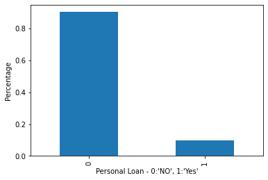

```python
print(df['Personal Loan'].value_counts(normalize=True)*100)
print()
df['Personal Loan'].value_counts(normalize=True).plot(kind='bar')
plt.xlabel("Personal Loan - 0:'NO', 1:'Yes'")
plt.ylabel("Percentage")
plt.show()
```

```python
df[df['Mortgage']==0].shape[0]

#count of people having home mortgage as zero, Most of the people donot have mortgage
```

```
3462
```

```python
pd.crosstab(df['Personal Loan'], df['CreditCard'],normalize='columns')
```

| CreditCard Personal Loan | 0 | 1 |
| --- | --- | --- |
| 0 | 0.904533 | 0.902721 |
| 1 | 0.095467 | 0.097279 |

`When CreditCard value is 0 or 1 in both cases the distribution of target variable is same therefore dropping CreditCard`

```python
df.drop('CreditCard',axis=1,inplace=True)
```

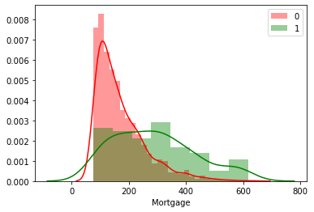

```python
sns.distplot(df[(df['Personal Loan']==0) & (df['Mortgage']>0)]['Mortgage'],color='r',label=0)
sns.distplot(df[  (df['Personal Loan']==1)  & (df['Mortgage']>0)   ]['Mortgage'],color='g',label=1)
plt.legend()
plt.show()

# Most people with zero motgage are not taking personal loans
```

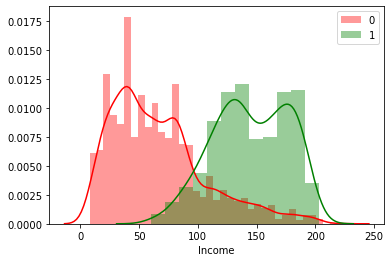

```python
sns.distplot(df[df['Personal Loan']==0]['Income'],color='r',label=0)
sns.distplot(df[df['Personal Loan']==1]['Income'],color='g',label=1)
plt.legend()
plt.show()

# Number of People with high income taking personal loan are high as compared to low income
```

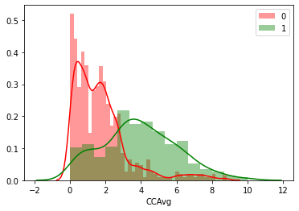

```python
sns.distplot(df[df['Personal Loan']==0]['CCAvg'],color='r',label=0)
sns.distplot(df[df['Personal Loan']==1]['CCAvg'],color='g',label=1)
plt.legend()
plt.show()

# People with high avg credit card spending per month are taking personal loans
```

```python
df[df['Mortgage']==0].shape[0]
```

```
3462
```

```python
df[df['CCAvg']==0].shape[0]

#count of people having zero monthly spending on credit card
```

```
106
```

```python
df.Family.value_counts()
```

```
1    1472
2    1296
4    1222
3    1010
Name: Family, dtype: int64
```

```python
df.Education.value_counts()
```

```
1    2096
3    1501
2    1403
Name: Education, dtype: int64
```

```python
df['Family'] = df['Family'].astype('category')
df['Education'] = df['Education'].astype('category')
```

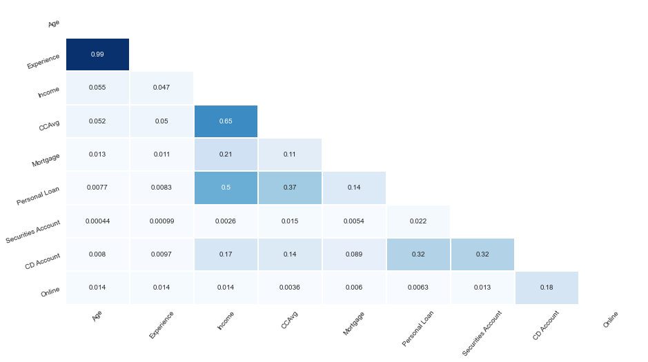

```python
corr = abs(df.corr()) # correlation matrix
lower_triangle = np.tril(corr, k = -1)  # select only the lower triangle of the correlation matrix
mask = lower_triangle == 0  # to mask the upper triangle in the following heatmap

plt.figure(figsize = (15,8))  # setting the figure size
sns.set_style(style = 'white')  # Setting it to white so that we do not see the grid lines
sns.heatmap(lower_triangle, center=0.5, cmap= 'Blues', annot= True, xticklabels = corr.index, yticklabels = corr.columns,
            cbar= False, linewidths= 1, mask = mask)   # Da Heatmap
plt.xticks(rotation = 50)   # Aesthetic purposes
plt.yticks(rotation = 20)   # Aesthetic purposes
plt.show()
```

`Age and Experience has 0.99 correlation therefore dropping Experience`

```python
df.drop('Experience',axis=1,inplace=True)
```

```python
df.Mortgage.value_counts()
```

```
0      3462
98       17
103      16
119      16
83       16
       ...
541       1
509       1
505       1
485       1
577       1
Name: Mortgage, Length: 347, dtype: int64
```

```python
## Additional

### New variable extracted from mortgage

df['Mortgage_category'] = df['Mortgage'].apply(lambda x:1 if x>0 else 0)
# Here, lambda function gives output as 1 whenever 'Mortgage' value is greater than or equal to 1 else it gives 0
## These outputs are stored ina new column 'Mortgage_category'

df['Mortgage_category'] = df['Mortgage_category'].astype('category') # Converting column to 'category' datatype

df['Mortgage_category'].value_counts()
```

```
0    3462
1    1538
Name: Mortgage_category, dtype: int64
```

```python
pd.crosstab(df['Personal Loan'], df['Mortgage_category'],normalize='columns')
```

| Mortgage_category Personal Loan | 0 | 1 |
| --- | --- | --- |
| 0 | 0.909879 | 0.890767 |
| 1 | 0.090121 | 0.109233 |

```python
del df['Mortgage_category']
```

```python
pd.crosstab(df['Personal Loan'], df['Family'],normalize='columns')
```

| Family Personal Loan | 1 | 2 | 3 | 4 |
| --- | --- | --- | --- | --- |
| 0 | 0.92731 | 0.91821 | 0.868317 | 0.890344 |
| 1 | 0.07269 | 0.08179 | 0.131683 | 0.109656 |

```python
pd.crosstab(df['Personal Loan'], df['Education'],normalize='columns')
```

| Education Personal Loan | 1 | 2 | 3 |
| --- | --- | --- | --- |
| 0 | 0.95563 | 0.870278 | 0.863424 |
| 1 | 0.04437 | 0.129722 | 0.136576 |

```python
pd.crosstab(df['Personal Loan'], df['Securities Account'],normalize='columns')
```

| Securities Account Personal Loan | 0 | 1 |
| --- | --- | --- |
| 0 | 0.906208 | 0.885057 |
| 1 | 0.093792 | 0.114943 |

```python
pd.crosstab(df['Personal Loan'], df['Online'],normalize='columns')
```

| Online Personal Loan | 0 | 1 |
| --- | --- | --- |
| 0 | 0.90625 | 0.90248 |
| 1 | 0.09375 | 0.09752 |

```python
del df['Online']
```

```python
df.columns
```

```
Index(['Age', 'Income', 'Family', 'CCAvg', 'Education', 'Mortgage',
       'Personal Loan', 'Securities Account', 'CD Account'],
      dtype='object')
```

### 3. Split the data into training and test set in the ratio of 70:30 respectively (5 marks)

```python
# Separate the independent attributes i.e. every column except personal loan
# Store the target column (Personal Loan) into Y array

x = df.loc[:, df.columns != 'Personal Loan']  # independent variables

y = df.loc[:, df.columns == 'Personal Loan']  # Target variable
```

```python
x
```

|  | Age | Income | Family | CCAvg | Education | Mortgage | Securities Account | CD Account |
| --- | --- | --- | --- | --- | --- | --- | --- | --- |
| 0 | 25 | 49 | 4 | 1.6 | 1 | 0 | 1 | 0 |
| 1 | 45 | 34 | 3 | 1.5 | 1 | 0 | 1 | 0 |
| 2 | 39 | 11 | 1 | 1.0 | 1 | 0 | 0 | 0 |
| 3 | 35 | 100 | 1 | 2.7 | 2 | 0 | 0 | 0 |
| 4 | 35 | 45 | 4 | 1.0 | 2 | 0 | 0 | 0 |
| ... | ... | ... | ... | ... | ... | ... | ... | ... |
| 4995 | 29 | 40 | 1 | 1.9 | 3 | 0 | 0 | 0 |
| 4996 | 30 | 15 | 4 | 0.4 | 1 | 85 | 0 | 0 |
| 4997 | 63 | 24 | 2 | 0.3 | 3 | 0 | 0 | 0 |
| 4998 | 65 | 49 | 3 | 0.5 | 2 | 0 | 0 | 0 |
| 4999 | 28 | 83 | 3 | 0.8 | 1 | 0 | 0 | 0 |

5000 rows × 8 columns

```python
x = pd.get_dummies(x,drop_first=True)
```

```python
x.head()
```

|  | Age | Income | CCAvg | Mortgage | Securities Account | CD Account | Family_2 | Family_3 | Family_4 | Education_2 | Education_3 |
| --- | --- | --- | --- | --- | --- | --- | --- | --- | --- | --- | --- |
| 0 | 25 | 49 | 1.6 | 0 | 1 | 0 | 0 | 0 | 1 | 0 | 0 |
| 1 | 45 | 34 | 1.5 | 0 | 1 | 0 | 0 | 1 | 0 | 0 | 0 |
| 2 | 39 | 11 | 1.0 | 0 | 0 | 0 | 0 | 0 | 0 | 0 | 0 |
| 3 | 35 | 100 | 2.7 | 0 | 0 | 0 | 0 | 0 | 0 | 1 | 0 |
| 4 | 35 | 45 | 1.0 | 0 | 0 | 0 | 0 | 0 | 1 | 1 | 0 |

```python
y.head()
```

|  | Personal Loan |
| --- | --- |
| 0 | 0 |
| 1 | 0 |
| 2 | 0 |
| 3 | 0 |
| 4 | 0 |

```python
x.head()
```

|  | Age | Income | CCAvg | Mortgage | Securities Account | CD Account | Family_2 | Family_3 | Family_4 | Education_2 | Education_3 |
| --- | --- | --- | --- | --- | --- | --- | --- | --- | --- | --- | --- |
| 0 | 25 | 49 | 1.6 | 0 | 1 | 0 | 0 | 0 | 1 | 0 | 0 |
| 1 | 45 | 34 | 1.5 | 0 | 1 | 0 | 0 | 1 | 0 | 0 | 0 |
| 2 | 39 | 11 | 1.0 | 0 | 0 | 0 | 0 | 0 | 0 | 0 | 0 |
| 3 | 35 | 100 | 2.7 | 0 | 0 | 0 | 0 | 0 | 0 | 1 | 0 |
| 4 | 35 | 45 | 1.0 | 0 | 0 | 0 | 0 | 0 | 1 | 1 | 0 |

### 4. Use the Logistic Regression model to predict whether the customer will take a personal loan or not. Print all the metrics related to evaluating the model performance (accuracy, recall, precision, f1score, and roc_auc_score). Draw a heatmap to display confusion matrix (15 marks)

```python
# Create the training and test data set in the ratio of 70:30 respectively. Can be of any ratio...

from sklearn.model_selection import train_test_split

xtrain,xtest,ytrain,ytest = train_test_split(x,y,test_size=0.3,random_state=7)

# Random state seeding for reapeatability of the code
# if random state is not mentioned it would generate different train test sample in every run
# test_size is to select the size of test data

# two variables taken for split therefore output will generate 4 variables: test train for x and test train for y
```

```python
xtrain.head()
```

|  | Age | Income | CCAvg | Mortgage | Securities Account | CD Account | Family_2 | Family_3 | Family_4 | Education_2 | Education_3 |
| --- | --- | --- | --- | --- | --- | --- | --- | --- | --- | --- | --- |
| 717 | 59 | 94 | 0.5 | 0 | 0 | 0 | 0 | 1 | 0 | 0 | 0 |
| 2496 | 63 | 32 | 0.7 | 141 | 0 | 0 | 0 | 1 | 0 | 1 | 0 |
| 2469 | 43 | 89 | 0.1 | 307 | 0 | 0 | 0 | 0 | 0 | 1 | 0 |
| 1375 | 50 | 179 | 2.9 | 0 | 0 | 0 | 0 | 0 | 0 | 0 | 1 |
| 2742 | 39 | 89 | 0.4 | 0 | 0 | 0 | 1 | 0 | 0 | 0 | 0 |

```python
xtest.head()
```

|  | Age | Income | CCAvg | Mortgage | Securities Account | CD Account | Family_2 | Family_3 | Family_4 | Education_2 | Education_3 |
| --- | --- | --- | --- | --- | --- | --- | --- | --- | --- | --- | --- |
| 3406 | 42 | 34 | 2.0 | 0 | 0 | 0 | 0 | 1 | 0 | 0 | 1 |
| 757 | 52 | 81 | 1.8 | 0 | 1 | 0 | 0 | 1 | 0 | 1 | 0 |
| 3624 | 58 | 70 | 1.4 | 0 | 0 | 0 | 0 | 0 | 0 | 0 | 1 |
| 4544 | 28 | 80 | 2.5 | 0 | 0 | 0 | 0 | 1 | 0 | 0 | 0 |
| 3235 | 60 | 39 | 1.6 | 0 | 0 | 0 | 1 | 0 | 0 | 0 | 1 |

#### Base Model

```python
from sklearn.linear_model import LogisticRegression   # importing logistic regression from scikit learn

model = LogisticRegression(random_state=7)  #assigning a variable for the algorithm

model.fit(xtrain, ytrain) #training of model
```

```
LogisticRegression(random_state=7)
```

```python
y_predict = model.predict(xtest)     #model is predicting y values based on test dataset given to the model

print("Trainig accuracy",model.score(xtrain,ytrain))  # this will give training accuracy as training data has been used
print()
print("Testing accuracy",model.score(xtest, ytest))   # this will give testing accuracy as testing data has been used
```

```
Trainig accuracy 0.9537142857142857

Testing accuracy 0.9586666666666667
```

```python
#### Here the model performs better in testing than training. Therefore, it is a good model
```

```python
from sklearn.metrics import confusion_matrix, recall_score, precision_score, f1_score, roc_auc_score

## importing necessary metrics to evaluate model performance
```

```python
## function to get confusion matrix in a proper format
def draw_cm( actual, predicted ):
    cm = confusion_matrix( actual, predicted)
    sns.heatmap(cm, annot=True,  fmt='.2f', xticklabels = [0,1] , yticklabels = [0,1] )
    plt.ylabel('Observed')
    plt.xlabel('Predicted')
    plt.show()
```

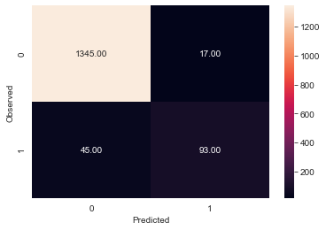

```python
draw_cm(ytest,y_predict)
```

```python
recall_score(ytest,y_predict)
```

```
0.6739130434782609
```

```python
precision_score(ytest,y_predict)
```

```
0.8454545454545455
```

```python
f1_score(ytest,y_predict)
```

```
0.75
```

```python
roc_auc_score(ytest,y_predict)
```

```
0.8307156994190129
```

```python
# !pip install yellowbrick
```

```python
# Additional

from yellowbrick.classifier import ClassificationReport
# Visualize model performance with yellowbrick library
viz = ClassificationReport(model)
viz.fit(xtrain, ytrain)
viz.score(xtest, ytest)
viz.show()
```

[output not shown]

### 5. Find out coefficients of all the attributes and show the output in a data frame with column names? For test data show all the rows where the predicted class is not equal to the observed class. (10 marks)

```python
## Feature Importance or Coefficients
fi = pd.DataFrame()
fi['Col'] = xtrain.columns
fi['Coeff'] = np.round(abs(model.coef_[0]),7)
fi['rawCoeff'] = np.round((model.coef_[0]),7)
fi['Coeffimpact'] = np.exp(fi['rawCoeff'])-1

fi.sort_values(by='Coeff',ascending=False) # stats models logistic regression returns the range for coefficients
```

|  | Col | Coeff | rawCoeff | Coeffimpact |
| --- | --- | --- | --- | --- |
| 10 | Education_3 | 3.373696 | 3.373696 | 28.186188 |
| 5 | CD Account | 3.092026 | 3.092026 | 21.021642 |
| 9 | Education_2 | 3.011532 | 3.011532 | 19.318510 |
| 4 | Securities Account | 1.307636 | -1.307636 | -0.729541 |
| 8 | Family_4 | 0.690881 | 0.690881 | 0.995473 |
| 6 | Family_2 | 0.548989 | -0.548989 | -0.422467 |
| 7 | Family_3 | 0.529430 | 0.529430 | 0.697964 |
| 2 | CCAvg | 0.185555 | 0.185555 | 0.203887 |
| 1 | Income | 0.048701 | 0.048701 | 0.049906 |
| 0 | Age | 0.005219 | 0.005219 | 0.005232 |
| 3 | Mortgage | 0.000976 | 0.000976 | 0.000977 |

```python
# Observe the predicted and observed classes in a dataframe.

z = xtest.copy()
z['Observed Loan Status'] = ytest
z['Predicted Loan Status'] = y_predict
z.tail(10)
```

|  | Age | Income | CCAvg | Mortgage | Securities Account | CD Account | Family_2 | Family_3 | Family_4 | Education_2 | Education_3 | Observed Loan Status | Predicted Loan Status |
| --- | --- | --- | --- | --- | --- | --- | --- | --- | --- | --- | --- | --- | --- |
| 4161 | 32 | 61 | 2.6 | 0 | 0 | 0 | 0 | 1 | 0 | 1 | 0 | 0 | 0 |
| 2750 | 57 | 24 | 0.1 | 0 | 0 | 0 | 0 | 0 | 0 | 1 | 0 | 0 | 0 |
| 987 | 62 | 84 | 2.8 | 0 | 0 | 0 | 1 | 0 | 0 | 0 | 0 | 0 | 0 |
| 2787 | 60 | 152 | 6.9 | 0 | 0 | 0 | 1 | 0 | 0 | 0 | 0 | 0 | 0 |
| 2699 | 37 | 22 | 0.1 | 114 | 0 | 0 | 0 | 1 | 0 | 1 | 0 | 0 | 0 |
| 460 | 60 | 141 | 2.1 | 0 | 0 | 0 | 1 | 0 | 0 | 0 | 0 | 0 | 0 |
| 2492 | 28 | 134 | 3.1 | 0 | 0 | 0 | 1 | 0 | 0 | 0 | 0 | 0 | 0 |
| 3028 | 63 | 38 | 0.1 | 178 | 0 | 0 | 0 | 1 | 0 | 0 | 1 | 0 | 0 |
| 3437 | 57 | 39 | 0.7 | 0 | 1 | 0 | 0 | 0 | 1 | 1 | 0 | 0 | 0 |
| 4579 | 58 | 41 | 0.2 | 81 | 0 | 0 | 0 | 0 | 0 | 0 | 0 | 0 | 0 |

```python
z[z['Observed Loan Status']!=z['Predicted Loan Status']]
```

|  | Age | Income | CCAvg | Mortgage | Securities Account | CD Account | Family_2 | Family_3 | Family_4 | Education_2 | Education_3 | Observed Loan Status | Predicted Loan Status |
| --- | --- | --- | --- | --- | --- | --- | --- | --- | --- | --- | --- | --- | --- |
| 4575 | 53 | 115 | 0.5 | 0 | 0 | 0 | 1 | 0 | 0 | 0 | 1 | 1 | 0 |
| 78 | 54 | 133 | 2.6 | 0 | 0 | 0 | 1 | 0 | 0 | 0 | 1 | 1 | 0 |
| 3383 | 46 | 135 | 4.1 | 213 | 0 | 0 | 0 | 1 | 0 | 0 | 0 | 1 | 0 |
| 2304 | 27 | 170 | 4.7 | 0 | 0 | 0 | 0 | 1 | 0 | 0 | 0 | 1 | 0 |
| 1731 | 43 | 125 | 2.4 | 0 | 0 | 0 | 0 | 1 | 0 | 0 | 0 | 1 | 0 |
| ... | ... | ... | ... | ... | ... | ... | ... | ... | ... | ... | ... | ... | ... |
| 2194 | 34 | 123 | 1.6 | 0 | 0 | 0 | 0 | 0 | 0 | 1 | 0 | 1 | 0 |
| 927 | 65 | 95 | 3.7 | 138 | 0 | 0 | 0 | 1 | 0 | 1 | 0 | 1 | 0 |
| 3084 | 26 | 129 | 0.7 | 0 | 0 | 0 | 0 | 1 | 0 | 1 | 0 | 1 | 0 |
| 4163 | 54 | 108 | 1.9 | 0 | 0 | 0 | 0 | 0 | 1 | 1 | 0 | 1 | 0 |
| 2684 | 30 | 98 | 1.8 | 129 | 1 | 1 | 0 | 0 | 1 | 0 | 1 | 0 | 1 |

62 rows × 13 columns

`62 rows where predicted target variable is not equal to actual target variable`

### 6. Give conclusion related to the Business understanding of your model? (5 marks)

##### `Confusion matrix means`

*True Positive (observed=1,predicted=1):*

Predicted Personal loan will be taken and the customer took it

*False Positive (observed=0,predicted=1):*

Predicted Personal loan will be taken and the customer did not take it

*True Negative (observed=0,predicted=0):*

Predicted Personal loan will not be taken and the customer did not take it

*False Negative (observed=1,predicted=0):*

Predicted Personal loan will not be taken and the customer took it

##### `Important Features`

"Age" and "Mortgage" doesn't play any role in predicting the target variable.

##### `Important Metric`

Here more focus towards should be towards recall because our target variable is 'Personal Loan' , i.e whether the customer is accepting the personal loan or not. And the bank wants more people to accept personal loan i.e. **less number of False Negative**, so that bank doesn't lose real customers who want to take loan. Hence the **focus should be on increasing Recall**.

After achieving the desired accuracy we can deploy the model for practical use. As in the bank now can predict who will say yes for the personnel loan. They can use the model for upcoming customers.

## Appendix:

- **warnings.filterwarnings("ignore")** : Never print matching warnings.
- **Pandas** : Pandas is an open source library providing high-performance, easy-to-use data structures and data analysis tools for the Python programming language.
- **Numpy** : The fundamental package for scientific computing with Python.
- **Matplotlib** : Matplotlib is a comprehensive library for creating static, animated, and interactive visualizations in Python.
- **Seaborn** : Seaborn is a Python data visualization library based on matplotlib. It provides a high-level interface for drawing attractive and informative statistical graphics.
- **pairplot** : Plot pairwise relationships in a dataset.
- **heatmap** : Draw a heatmap of rectangular data as a color-encoded matrix.
- **distplot** : Flexibly plot a univariate distribution of observations.
- **pandas.DataFrame.corr** : Compute pairwise correlation of columns, excluding NA/null values.
- **sklearn.linear_model.LogisticRegression** : Logistic Regression (aka logit, MaxEnt) classifier.
- **yellowbrick** : Yellowbrick extends the Scikit-Learn API to make model selection and hyperparameter tuning easier. Under the hood, it uses Matplotlib